# Tutorial 10: Cross-level interactions

Forschungspraktikum I und II: Vergleichende Sozialforschung mit Mehrebenenmodellen in R

Dr. Christian Czymara (Sociology with Focus on Quantitative Methods for Social Research, Goethe University Frankfurt)

In this exercise, we will replicate [Czymara (2020)](https://journals.sagepub.com/doi/10.1177/0197918319890270). This study examines how discourses of a country’s political elites translate into natives’ attitudes toward Muslim immigrants (`almuslv`), based on data from the seventh wave of the European Social Survey and the [Comparative Manifestos Project](https://manifesto-project.wzb.eu/).

## 1. Data preparation

### a) Import data

Import PropPref_reduc.dta and assign it to object `ESS_CMP`. The main two country-level predictors of the study are political elite discourses that are exclusionary (`std2_ExclusionDisc`) or inclusionary (`std2_InclusionDisc`). Country-level control variables are share of foreigners (`std2_forpop13_pol11`), share of Muslims (`std2_perc_muslim_v3`) and unemployment rate (`std2_unemployment14`). All these continuous variables are standardized so that they range from 0 to 1, where 0 is the minimum of original variable and 1 the maximum of original variable. Compare `ExclusionDisc` (original version of variable) and `std2_ExclusionDisc` (standardized version of variable).

```r
setwd("C:/Users/czymara.local/Nextcloud/teaching/FoP HLM/_R/10_cross-level_interactions")

library("haven")

ESS_CMP <- read_dta("PropPref_reduc.dta")

table(round(ESS_CMP$ExclusionDisc, 2), round(ESS_CMP$std2_ExclusionDisc, 2))
```

```
##
##            0 0.08 0.09 0.11 0.12 0.16 0.18 0.22 0.27  0.3 0.33 0.35 0.36  0.4
##   5.68  1272    0    0    0    0    0    0    0    0    0    0    0    0    0
##   12.78    0 1471    0    0    0    0    0    0    0    0    0    0    0    0
##   13.78    0    0 1131    0    0    0    0    0    0    0    0    0    0    0
##   15.97    0    0    0 1563    0    0    0    0    0    0    0    0    0    0
##   16.62    0    0    0    0 1275    0    0    0    0    0    0    0    0    0
##   20.2     0    0    0    0    0  936    0    0    0    0    0    0    0    0
##   22.72    0    0    0    0    0    0  721    0    0    0    0    0    0    0
##   25.53    0    0    0    0    0    0    0 1310    0    0    0    0    0    0
##   30.61    0    0    0    0    0    0    0    0 1455    0    0    0    0    0
##   32.92    0    0    0    0    0    0    0    0    0 2291    0    0    0    0
##   35.95    0    0    0    0    0    0    0    0    0    0 1154    0    0    0
##   37.59    0    0    0    0    0    0    0    0    0    0    0 1284    0    0
##   39.29    0    0    0    0    0    0    0    0    0    0    0    0 1482    0
##   42.5     0    0    0    0    0    0    0    0    0    0    0    0    0 1795
##   70.91    0    0    0    0    0    0    0    0    0    0    0    0    0    0
##   78.06    0    0    0    0    0    0    0    0    0    0    0    0    0    0
##   78.42    0    0    0    0    0    0    0    0    0    0    0    0    0    0
##   96.69    0    0    0    0    0    0    0    0    0    0    0    0    0    0
##   97.9     0    0    0    0    0    0    0    0    0    0    0    0    0    0
##
##         0.71 0.78 0.79 0.99    1
##   5.68     0    0    0    0    0
##   12.78    0    0    0    0    0
##   13.78    0    0    0    0    0
##   15.97    0    0    0    0    0
##   16.62    0    0    0    0    0
##   20.2     0    0    0    0    0
##   22.72    0    0    0    0    0
##   25.53    0    0    0    0    0
##   30.61    0    0    0    0    0
##   32.92    0    0    0    0    0
##   35.95    0    0    0    0    0
##   37.59    0    0    0    0    0
##   39.29    0    0    0    0    0
##   42.5     0    0    0    0    0
##   70.91  813    0    0    0    0
##   78.06    0 1215    0    0    0
##   78.42    0    0 1214    0    0
##   96.69    0    0    0 1172    0
##   97.9     0    0    0    0  975
```

### b) Create factors

We will later add a couple of categorical control variables: `polintr`, `dfegcf`, `res_unempl`, `res_educ`, `hincfel`. Convert those variables to factors in the data frame `ESS_CMP` using the `as.factor()` function (this will be necessary for plotting the interaction later).

```r
ESS_CMP$polintr <- as.factor(ESS_CMP$polintr)
ESS_CMP$dfegcf <- as.factor(ESS_CMP$dfegcf)
ESS_CMP$res_unempl <- as.factor(ESS_CMP$res_unempl)
ESS_CMP$res_educ <- as.factor(ESS_CMP$res_educ)
ESS_CMP$hincfel <- as.factor(ESS_CMP$hincfel)
```

## 2. Main model

### a) Random intercept model with country level variables

Estimate a random intercept model that adds all country-level variables and interpret the effect of `std2_ExclusionDisc` and `std2_InclusionDisc`.

```r
library(lme4)

m1_country <- lmer(almuslv ~ std2_ExclusionDisc + std2_InclusionDisc + std2_forpop13_pol11 + std2_perc_muslim_v3 + std2_unemployment14 + (1 | country), data = ESS_CMP)

summary(m1_country, correlation = F)
```

```
## Linear mixed model fit by REML ['lmerMod']
## Formula:
## almuslv ~ std2_ExclusionDisc + std2_InclusionDisc + std2_forpop13_pol11 +
##     std2_perc_muslim_v3 + std2_unemployment14 + (1 | country)
##    Data: ESS_CMP
##
## REML criterion at convergence: 63335.7
##
## Scaled residuals:
##      Min       1Q   Median       3Q      Max
## -2.77776 -0.67945  0.09274  0.64252  2.47849
##
## Random effects:
##  Groups   Name        Variance Std.Dev.
##  country  (Intercept) 0.03195  0.1787
##  Residual             0.77170  0.8785
## Number of obs: 24529, groups:  country, 19
##
## Fixed effects:
##                     Estimate Std. Error t value
## (Intercept)           3.1520     0.1457  21.631
## std2_ExclusionDisc    0.4352     0.1556   2.797
## std2_InclusionDisc   -0.7683     0.1565  -4.908
## std2_forpop13_pol11   0.1356     0.2479   0.547
## std2_perc_muslim_v3  -0.8509     0.1613  -5.275
## std2_unemployment14  -0.2689     0.2370  -1.134
```

### b) Add individual level controls

Add the following individual-level control variables: `std2_lrscale`, `polintr`, `gndr`, `std2_agea`, `dfegcf`, `res_unempl`, `res_educ`, and `hincfel`. Are the results of the country-level effects stable to the inclusion of these variables?

```r
m2_ind <- lmer(almuslv ~ std2_ExclusionDisc + std2_InclusionDisc + std2_forpop13_pol11 + std2_perc_muslim_v3 + std2_unemployment14 + std2_lrscale + polintr + gndr + std2_agea + dfegcf + res_unempl + res_educ + hincfel + (1 | country), data = ESS_CMP)

library(sjPlot)

tab_model(m1_country, m2_ind)
```

|  | Allow many or few Muslims to come and live in country |  |  | Allow many or few Muslims to come and live in country |  |  |
| --- | --- | --- | --- | --- | --- | --- |
| Predictors | Estimates | CI | p | Estimates | CI | p |
| (Intercept) | 3.15 | 2.87 – 3.44 | **<0.001** | 1.58 | 1.35 – 1.81 | **<0.001** |
| std 2 Exclusion Disc | 0.44 | 0.13 – 0.74 | **0.005** | 0.42 | 0.18 – 0.66 | **0.001** |
| std 2 Inclusion Disc | -0.77 | -1.08 – -0.46 | **<0.001** | -0.59 | -0.83 – -0.35 | **<0.001** |
| std 2 forpop 13 pol 11 | 0.14 | -0.35 – 0.62 | 0.585 | 0.17 | -0.21 – 0.55 | 0.384 |
| std 2 perc muslim v 3 | -0.85 | -1.17 – -0.53 | **<0.001** | -0.64 | -0.88 – -0.39 | **<0.001** |
| std 2 unemployment 14 | -0.27 | -0.73 – 0.20 | 0.257 | -0.19 | -0.56 – 0.17 | 0.295 |
| std 2 lrscale |  |  |  | 0.57 | 0.53 – 0.62 | **<0.001** |
| polintr: polintr 2 |  |  |  | 0.10 | 0.06 – 0.13 | **<0.001** |
| polintr: polintr 3 |  |  |  | 0.23 | 0.20 – 0.27 | **<0.001** |
| polintr: polintr 4 |  |  |  | 0.38 | 0.34 – 0.43 | **<0.001** |
| Gender |  |  |  | -0.00 | -0.02 – 0.02 | 0.779 |
| std 2 agea |  |  |  | 0.66 | 0.61 – 0.71 | **<0.001** |
| dfegcf: dfegcf 2 |  |  |  | 0.21 | 0.18 – 0.25 | **<0.001** |
| dfegcf: dfegcf 3 |  |  |  | 0.43 | 0.40 – 0.47 | **<0.001** |
| res unempl: res unempl 1 |  |  |  | -0.02 | -0.07 – 0.03 | 0.392 |
| res educ: res educ 2 |  |  |  | 0.21 | 0.17 – 0.24 | **<0.001** |
| res educ: res educ 3 |  |  |  | 0.33 | 0.30 – 0.36 | **<0.001** |
| res educ: res educ 4 |  |  |  | 0.40 | 0.37 – 0.43 | **<0.001** |
| hincfel: hincfel 2 |  |  |  | 0.11 | 0.09 – 0.13 | **<0.001** |
| hincfel: hincfel 3 |  |  |  | 0.20 | 0.16 – 0.23 | **<0.001** |
| hincfel: hincfel 4 |  |  |  | 0.38 | 0.32 – 0.44 | **<0.001** |
| Random Effects |  |  |  |  |  |  |
| σ<sup>2</sup> | 0.77 |  |  | 0.64 |  |  |
| τ<sub>00</sub> | 0.03 <sub>country</sub> |  |  | 0.02 <sub>country</sub> |  |  |
| ICC | 0.04 |  |  | 0.03 |  |  |
| N | 19 <sub>country</sub> |  |  | 19 <sub>country</sub> |  |  |
| Observations | 24529 |  |  | 24529 |  |  |
| Marginal R<sup>2</sup> / Conditional R<sup>2</sup> | 0.135 / 0.170 |  |  | 0.282 / 0.303 |  |  |

## 3. Interaction of political orientation and exclusionary discourse

### a) Interaction model

In the paper, I argue that political elite discourses should have a stronger impact on one’s attitude if they are congruent with one’s existing ideology. Thus, *“the link between an exclusionary political elite discourse and attitudes should be stronger for those belonging to the political right”* (page 1217). Add an interaction between individual ideology (`std2_lrscale`) and exclusionary national political discourses (`std2_ExclusionDisc`) to test this hypothesis. Treat both as continuous. Interpret the result.

```r
str(ESS_CMP$lrscale)
```

```
##  dbl+lbl [1:24529]  4,  0,  7, 10,  5,  4,  5,  2,  5,  5,  7,  5,  5,  5, ...
##  @ label       : chr "Placement on left right scale"
##  @ format.stata: chr "%10.0g"
##  @ labels      : Named num [1:14] 0 1 2 3 4 5 6 7 8 9 ...
##   ..- attr(*, "names")= chr [1:14] "Left" "1" "2" "3" ...
```

```r
m3_int <- lmer(almuslv ~ std2_ExclusionDisc + std2_lrscale + std2_ExclusionDisc*std2_lrscale + std2_InclusionDisc + std2_forpop13_pol11 + std2_perc_muslim_v3 + std2_unemployment14 + polintr + gndr + std2_agea + dfegcf + res_unempl + res_educ + hincfel + (1 | country), data = ESS_CMP)

summary(m3_int, correlation = F)
```

```
## Linear mixed model fit by REML ['lmerMod']
## Formula: almuslv ~ std2_ExclusionDisc + std2_lrscale + std2_ExclusionDisc *
##     std2_lrscale + std2_InclusionDisc + std2_forpop13_pol11 +
##     std2_perc_muslim_v3 + std2_unemployment14 + polintr + gndr +
##     std2_agea + dfegcf + res_unempl + res_educ + hincfel + (1 |      country)
##    Data: ESS_CMP
##
## REML criterion at convergence: 58941.3
##
## Scaled residuals:
##     Min      1Q  Median      3Q     Max
## -3.6402 -0.6954  0.0114  0.7119  3.7170
##
## Random effects:
##  Groups   Name        Variance Std.Dev.
##  country  (Intercept) 0.01925  0.1387
##  Residual             0.64301  0.8019
## Number of obs: 24529, groups:  country, 19
##
## Fixed effects:
##                                 Estimate Std. Error t value
## (Intercept)                      1.64183    0.11909  13.787
## std2_ExclusionDisc               0.24502    0.12913   1.897
## std2_lrscale                     0.46006    0.03815  12.059
## std2_InclusionDisc              -0.59187    0.12208  -4.848
## std2_forpop13_pol11              0.16629    0.19337   0.860
## std2_perc_muslim_v3             -0.63361    0.12577  -5.038
## std2_unemployment14             -0.20448    0.18479  -1.107
## polintr2                         0.09609    0.01666   5.767
## polintr3                         0.23318    0.01797  12.978
## polintr4                         0.38472    0.02166  17.765
## gndr                            -0.00199    0.01046  -0.190
## std2_agea                        0.66347    0.02644  25.095
## dfegcf2                          0.21384    0.01836  11.649
## dfegcf3                          0.43249    0.01828  23.655
## res_unempl1                     -0.02074    0.02346  -0.884
## res_educ2                        0.20918    0.01771  11.809
## res_educ3                        0.33035    0.01444  22.883
## res_educ4                        0.39624    0.01602  24.739
## hincfel2                         0.10967    0.01229   8.925
## hincfel3                         0.19909    0.01776  11.210
## hincfel4                         0.37742    0.03017  12.508
## std2_ExclusionDisc:std2_lrscale  0.32120    0.08297   3.871
```

### b) Plotting the interaction

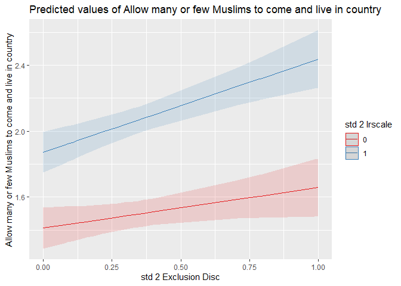

```r
plot_model(m3_int, type = "int")
```

### c) Effect of political orientation for least and most exclusionary country

- In the *least exclusionary* country (minimum of `std2_ExclusionDisc`)
- Which country is it?
- In the *most exclusionary* country (maximum of `std2_ExclusionDisc`)
- Which country is it?

```r
# convert labels to values for country variable
library(sjlabelled)
ESS_CMP$cntry <- as.factor(to_character(ESS_CMP$country))


# install and load marginaleffects
if(!require(marginaleffects)){
    install.packages("marginaleffects")
    library(marginaleffects)
  }

# predict marginal effects conditional on std2_ExclusionDisc
marginaleffects <- marginaleffects(m3_int, at = list(
  std2_ExclusionDisc = c(0, 1)))

# effect of std2_lrscale for least exclusionary country
mean(marginaleffects[marginaleffects$term == "std2_lrscale" &
                       marginaleffects$std2_ExclusionDisc == 0,
                     "dydx"])
```

```
## [1] 0.460059
```

```r
round(mean(marginaleffects[marginaleffects$term == "std2_lrscale" &
                       marginaleffects$std2_ExclusionDisc == 0,
                     "dydx"]), 10) == round(m3_int@beta[3], 10) # equals main effect of std2_lrscale
```

```
## [1] TRUE
```

```r
# which country?
table(ESS_CMP[ESS_CMP$std2_ExclusionDisc == 0, "cntry"])
```

```
##
##        Austria        Belgium Czech Republic        Denmark        Estonia
##              0              0              0              0              0
##        Finland         France        Germany        Hungary        Ireland
##              0              0              0              0              0
##    Netherlands         Norway         Poland       Portugal       Slovenia
##              0              0              0              0              0
##          Spain         Sweden    Switzerland United Kingdom
##           1272              0              0              0
```

```r
# most exclusionary
mean(marginaleffects[marginaleffects$term == "std2_lrscale" &
                       marginaleffects$std2_ExclusionDisc == 1,
                     "dydx"])
```

```
## [1] 0.7812539
```

```r
round(mean(marginaleffects[marginaleffects$term == "std2_lrscale" &
                       marginaleffects$std2_ExclusionDisc == 1,
                     "dydx"]), 10) == round(m3_int@beta[3] + tail(m3_int@beta, 1), 10)  # equals main effect of std2_lrscale + interaction effect
```

```
## [1] TRUE
```

```r
# which country?
table(ESS_CMP[ESS_CMP$std2_ExclusionDisc == 1, "cntry"])
```

```
##
##        Austria        Belgium Czech Republic        Denmark        Estonia
##              0              0              0              0            975
##        Finland         France        Germany        Hungary        Ireland
##              0              0              0              0              0
##    Netherlands         Norway         Poland       Portugal       Slovenia
##              0              0              0              0              0
##          Spain         Sweden    Switzerland United Kingdom
##              0              0              0              0
```

```r
## alternatively: margins
library("margins")

marginaleffects <- margins(m3_int, at = list(std2_ExclusionDisc = c(0, 1)))

# least
marginaleffects[marginaleffects$std2_ExclusionDisc == 0, "dydx_std2_lrscale"][1]
```

```
## [1] 0.460059
```

```r
# most
marginaleffects[marginaleffects$std2_ExclusionDisc == 1, "dydx_std2_lrscale"][1]
```

```
## [1] 0.7812539
```

## 4. Random slope model

### a) Varying effect of political orientation

So far, so good. However, reviewers correctly pointed out that that cross-level interactions should include a random slope. Hence, add a random slope for the `std2_lrscale` variable and re-run the model. Are the results stable?

```r
m4_int_rs <- lmer(almuslv ~ std2_ExclusionDisc + std2_lrscale + std2_ExclusionDisc*std2_lrscale + std2_InclusionDisc + std2_forpop13_pol11 + std2_perc_muslim_v3 + std2_unemployment14 + polintr + gndr + std2_agea + dfegcf + res_unempl + res_educ + hincfel + (1 + std2_lrscale | country), data = ESS_CMP)

summary(m4_int_rs, correlation = F)
```

```
## Linear mixed model fit by REML ['lmerMod']
## Formula: almuslv ~ std2_ExclusionDisc + std2_lrscale + std2_ExclusionDisc *
##     std2_lrscale + std2_InclusionDisc + std2_forpop13_pol11 +
##     std2_perc_muslim_v3 + std2_unemployment14 + polintr + gndr +
##     std2_agea + dfegcf + res_unempl + res_educ + hincfel + (1 +
##     std2_lrscale | country)
##    Data: ESS_CMP
##
## REML criterion at convergence: 58781.1
##
## Scaled residuals:
##     Min      1Q  Median      3Q     Max
## -3.6561 -0.6990  0.0147  0.7064  3.6525
##
## Random effects:
##  Groups   Name         Variance Std.Dev. Corr
##  country  (Intercept)  0.05468  0.2338
##           std2_lrscale 0.14589  0.3820   -0.81
##  Residual              0.63766  0.7985
## Number of obs: 24529, groups:  country, 19
##
## Fixed effects:
##                                  Estimate Std. Error t value
## (Intercept)                      1.641981   0.137013  11.984
## std2_ExclusionDisc               0.274857   0.191054   1.439
## std2_lrscale                     0.497382   0.144727   3.437
## std2_InclusionDisc              -0.599960   0.121228  -4.949
## std2_forpop13_pol11              0.154519   0.192067   0.805
## std2_perc_muslim_v3             -0.647890   0.124883  -5.188
## std2_unemployment14             -0.182544   0.183523  -0.995
## polintr2                         0.096371   0.016607   5.803
## polintr3                         0.230890   0.017910  12.892
## polintr4                         0.380249   0.021599  17.605
## gndr                            -0.000312   0.010424  -0.030
## std2_agea                        0.648205   0.026435  24.521
## dfegcf2                          0.211171   0.018292  11.545
## dfegcf3                          0.427126   0.018219  23.444
## res_unempl1                     -0.017499   0.023374  -0.749
## res_educ2                        0.204675   0.017658  11.591
## res_educ3                        0.320928   0.014416  22.262
## res_educ4                        0.389829   0.015976  24.402
## hincfel2                         0.111797   0.012247   9.129
## hincfel3                         0.197070   0.017698  11.135
## hincfel4                         0.371587   0.030079  12.354
## std2_ExclusionDisc:std2_lrscale  0.289618   0.297806   0.973
```

### b) Re-plotting the interaction

Again plot the effect political orientation conditional on discourse like in 3.b) but this time with the appropriate model including a random slope.

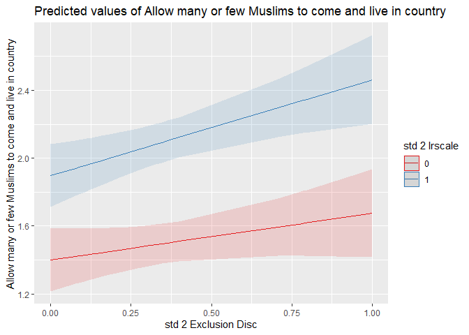

```r
plot_model(m4_int_rs, type = "int")
```

### Supplement: original code

By the way, the study’s analysis was originally performed with Stata. Full Code is available [here](https://osf.io/8fmt9/).